# Part 2 - ASA Short Course Second-generation p-values (Full-Day)

# Introduction

- Jeffrey D. Blume, PhD
  - School of Data Science, University of Virginia
- Megan H. Murray, PhD
  - Department of Biostatistics, Vanderbilt University

Resources:

- GitHub with Slides and Code: www.github.com/murraymegan/SGPV-ASA-Short-Course
- RStudio Desktop: www.rstudio.com/products/rstudio/download
- Interrupt or use Zoom chat for questions!
- For technical difficulties email Megan: megan.c.hollister@vanderbilt.edu

## SGPV Package

Functions Included:

- `sgpvalue()`
  - This function computes the second-generation p-value (SGPV) and its associated delta gaps, as introduced in Blume et al. (2018).
- `sgpower()`
  - Calculate power and type I error values from significance testing based on second-generation p-values as the inferential metric.
- `plotsgpv()`
  - This function displays user supplied interval estimates (support intervals, confidence intervals, credible intervals, etc.) according to its associated second-generation p-value ranking.
- `plotman()`
  - This function displays a modified Manhattan-style plot colored according to second-generation p-value status.
- `fdrisk()`
  - This function computes the false discovery risk (sometimes called the “empirical bayes FDR”) for a second-generation p-value of 0, or the false confirmation risk for a second-generation p-value of 1.

# 1 Part 2

## 1.1 Part 2a

### 1.1.1 Equivalence tests: TOST

- Establish bioequivalence between data and an established range
- Example: A pharmaceutical company tests for drug approval by comparing new drug’s performance to an approved drug’s performance
- Tests are ordinary, one-sided, α-level t-tests
- Flips the null and alternative hypotheses

```r
n=6
dat = rnorm(n, 0, 1)
a = t.test(dat)$conf.int[1]
b =  t.test(dat)$conf.int[2]

x_bar = mean(dat)
S = sd(dat)
Z = (b-x_bar)/(S/sqrt(n))

theta_p = 0.5*0.75
theta_m = -0.5*0.75

out_TOST = tsum_TOST(m1=x_bar,
            mu=0,
            sd1=S,
            n1=n,
            low_eqbound=theta_m,
            high_eqbound=theta_p,
            alpha=0.05,
            eqbound_type = "raw")

out_TOST$TOST
```

```
##                     t        SE df    p.value
## t-test     -0.7929328 0.2612257  5 0.46376367
## TOST Lower  0.6426074 0.2612257  5 0.27439088
## TOST Upper -2.2284731 0.2612257  5 0.03815564
```

```r
max(out_TOST$TOST$p.value[2], out_TOST$TOST$p.value[3])
```

```
## [1] 0.2743909
```

```r
out_sgpv = sgpvalue(est.lo=a,
                       est.hi=b,
                       null.lo=theta_m,
                       null.hi=theta_p)

out_sgpv
```

```
## $p.delta
## [1] 0.5584495
##
## $delta.gap
## [1] NA
```

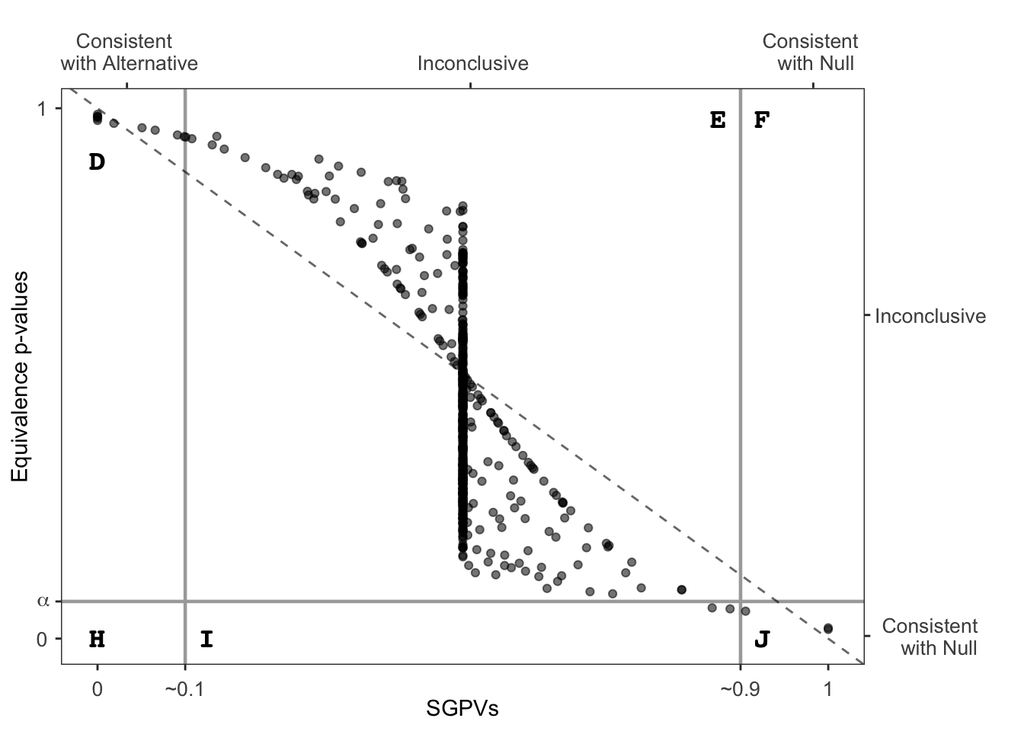

```r
set.seed(999)
iter=500
n=6
results = as.data.frame(matrix(ncol=2, nrow=iter))
colnames(results) = c("sgpv", "tost")
half.case = NULL
half.case2 = NULL

for(i in 1:iter){
  dat = rnorm(n, 0, 1)
  a = t.test(dat)$conf.int[1]
  b =  t.test(dat)$conf.int[2]
  x_bar = mean(dat)
  S = sd(dat)
  Z = (b-x_bar)/(S/sqrt(n))

  theta_p = 0.5*0.75
  theta_m = -0.5*0.75

  out_TOST = tsum_TOST(m1=x_bar,
            mu=0,
            sd1=S,
            n1=n,
            low_eqbound=theta_m,
            high_eqbound=theta_p,
            alpha=0.05,
            eqbound_type = "raw")

  out_sgpv = sgpvalue(est.lo=a,
                       est.hi=b,
                       null.lo=theta_m,
                       null.hi=theta_p)$p.delta

  results[i,1] = out_sgpv
  results[i,2] = pmax(out_TOST$TOST$p.value[2],out_TOST$TOST$p.value[3])
}


library(ggplot2)
scaleFUN <- function(x) sprintf("%.1f", x)

g = ggplot(results, aes(sgpv, tost))+
  xlab("SGPVs") +
  ylab("Equivalence p-values") +
  geom_point(aes(alpha=0.2)) +
  geom_abline(intercept = 1, slope = -1,linetype='dashed', alpha=0.6)+
  xlim(c(0,1))+
  scale_x_continuous(breaks= c( 0,0.120001,0.880001,1),labels=c("0", "~0.1", "~0.9", "1"), minor_breaks = c(0.12,0.88),
                      sec.axis=sec_axis(~./1, name="",breaks= c( 0.04,0.51,0.98), labels=c("Consistent \n with Alternative", "\n Inconclusive", "Consistent \n with Null")))+
  scale_y_continuous(breaks= c(0,0.07,1),  labels=c("0", expression(alpha), "1"),minor_breaks = c(0.070001),
                     sec.axis=sec_axis(~./1, name="", breaks= c(0.005,0.61), labels=c("Consistent \n with Null","Inconclusive")))+
  annotate(geom="text", x=0, y=0.9, label="D",
              size=5,
           family = "Courier-Bold")+
  annotate(geom="text", x=0.85, y=0.98, label="E",
              size=5,
           family = "Courier-Bold")+
  annotate(geom="text", x=0.91, y=0.98, label="F",
              size=5,
           family = "Courier-Bold")+
  annotate(geom="text", x=0, y=0, label="H",
              size=5,
           family = "Courier-Bold")+
  annotate(geom="text", x=0.15, y=0, label="I",
              size=5,
           family = "Courier-Bold")+
  annotate(geom="text", x=0.91, y=0, label="J",
              size=5,
           family = "Courier-Bold")+
  theme_bw()+
  theme(axis.text.y =  element_text(size=10, hjust=-0.5),
        axis.text.y.right =  element_text(size=10, hjust=0.7),
         axis.text.x.top =  element_text(size=10, vjust=2),
        axis.text.x =  element_text(size=10, vjust=-0.5),
        panel.grid.major = element_blank(),
        panel.grid.minor = element_line(size = 0.8,colour="darkgrey"))+
    guides(alpha=FALSE)
g
```

## 1.2 Part 2b

### 1.2.1 SGPV False Discovery Risk

- False Discovery Rate (FDR)
  - SGPV = 0
- False Confirmation Rate (FCR)
  - SGPV = 1
- `sgpv::fdrisk()`
  - This function computes the false discovery risk (sometimes called the “empirical bayes FDR”) for a second-generation p-value of 0, or the false confirmation risk for a second-generation p-value of 1.

```r
###### FDR rates
# false discovery risk with 95% confidence level
fdrisk(sgpval = 0,
       null.lo = log(1/1.1),
       null.hi = log(1.1),
       std.err = 0.8,
       null.weights = 'Uniform',
       null.space = c(log(1/1.1), log(1.1)),
       alt.weights = 'Uniform',
       alt.space = 2 + c(-1,1)*qnorm(1-0.05/2)*0.8,
       interval.type = 'confidence',
       interval.level = 0.05)
```

```
## [1] 0.05949861
```

```r
## with truncated normal weighting distribution
fdrisk(sgpval = 0,
       null.lo = log(1/1.1),
       null.hi = log(1.1),
       std.err = 0.8,
       null.weights = 'Point',
       null.space = 0,
       alt.weights = 'TruncNormal',
       alt.space = 2 + c(-1,1)*qnorm(1-0.041/2)*0.8,
       interval.type = 'likelihood',  interval.level = 1/8)
```

```
## [1] 0.04902575
```

```r
# false discovery risk with LSI and wider null hypothesis
fdrisk(sgpval = 0,
       null.lo = log(1/1.5),
       null.hi = log(1.5),
       std.err = 0.8,
       null.weights = 'Point',
       null.space = 0,
       alt.weights = 'Uniform',
       alt.space = 2.5 + c(-1,1)*qnorm(1-0.041/2)*0.8,
       interval.type = 'likelihood',  interval.level = 1/8)
```

```
## [1] 0.01688343
```

```r
# false confirmation risk example
fdrisk(sgpval = 1,
       null.lo = log(1/1.5),
       null.hi = log(1.5),
       std.err = 0.15,
       null.weights = 'Uniform',
       null.space = 0.01 + c(-1,1)*qnorm(1-0.041/2)*0.15,
       alt.weights = 'Uniform',
       alt.space = c(log(1.5), 1.25*log(1.5)),
       interval.type = 'likelihood',  interval.level = 1/8)
```

```
## [1] 0.03059522
```

```r
###
##
#
```

### 1.2.2 FDRestimation

Download the package from:

- https://cran.r-project.org/package=FDRestimation
- OR https://github.com/murraymegan/FDRestimation
- Our corresponding paper: https://f1000research.com/articles/10-441

```r
p.fdr.output = p.fdr(leukstats$p.value)

head(p.fdr.output$`Results Matrix`)
```

```
##     BH FDRs Adjusted p-values Raw p-values
## 1 0.1892484         0.1892484   0.05615324
## 2 0.9762477         0.9759186   0.93296848
## 3 0.6970430         0.6969894   0.47936375
## 4 0.2141365         0.2141365   0.06684255
## 5 0.9160462         0.9156422   0.81439179
## 6 0.6859496         0.6859383   0.46673059
```

```r
summary(p.fdr.output)
```

```
##
## Call:
## p.fdr(pvalues = leukstats$p.value)
##
## Number of tests: 7128
## Raw p-value Range: [0, 0.99964]
##
## Adjustment Method: BH
## False Discovery Rate Range: [0, 1]
## Findings at 0.05 level:
##    Significant (Reject): 1233
##    Inconclusive (Fail to Reject): 5895
## ---
## Estimated/Assumed Null Proportion (pi0): 1
```

#### Plots

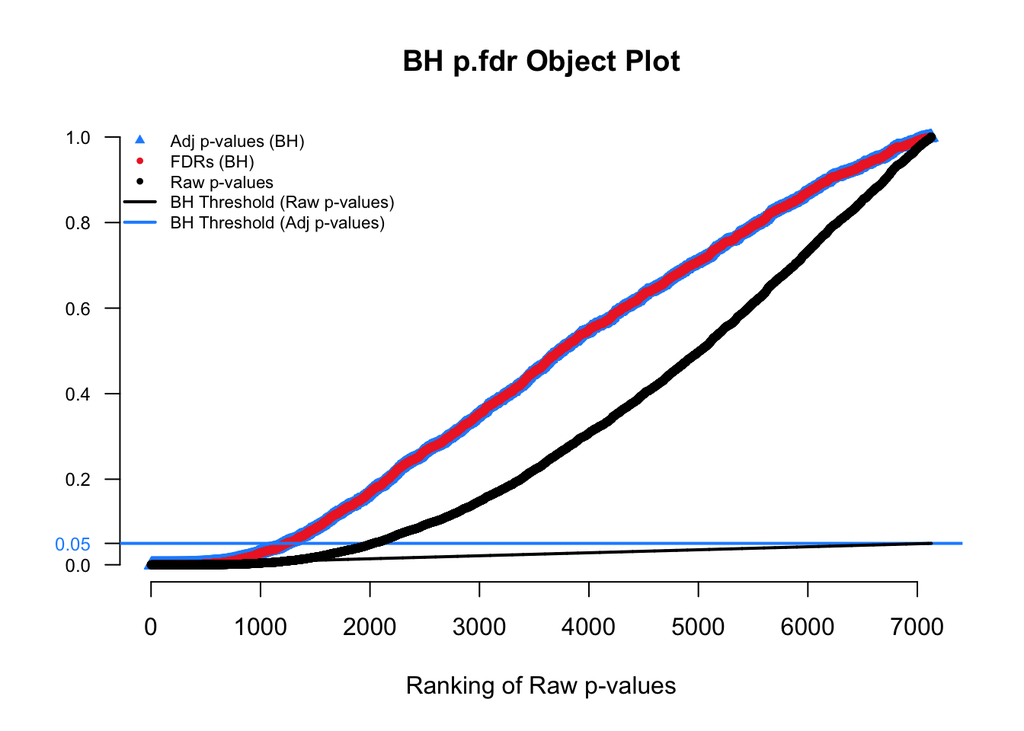

```r
plot(p.fdr.output)
```

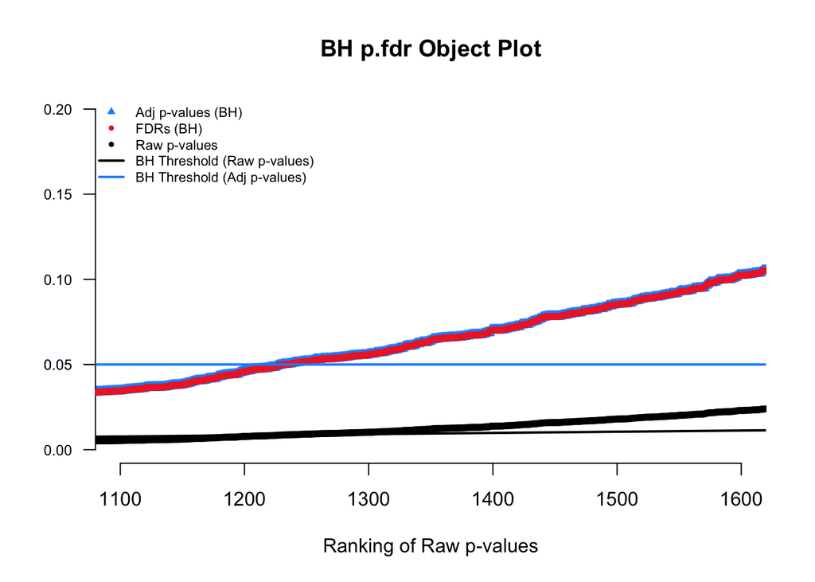

```r
plot(p.fdr.output, xlim=c(1100,1600), ylim=c(0, 0.2))
```

```r
which(-1*(p.fdr.output$`Results Matrix`$`Adjusted p-values`)+p.fdr.output$fdrs>0.001)
```

```
## integer(0)
```

```r
#Benjamini-Yeukatelli
p.fdr.output = p.fdr(leukstats$p.value, adjust.method = "BY")

head(p.fdr.output$`Results Matrix`)
```

```
##     BY FDRs BY Adjusted p-values Raw p-values   BH FDRs
## 1 0.1892484            0.1892484   0.05615324 0.1892484
## 2 1.0000000            1.0000000   0.93296848 0.9762477
## 3 1.0000000            1.0000000   0.47936375 0.6970430
## 4 0.4461177            0.4461177   0.06684255 0.2141365
## 5 1.0000000            1.0000000   0.81439179 0.9160462
## 6 1.0000000            1.0000000   0.46673059 0.6859496
```

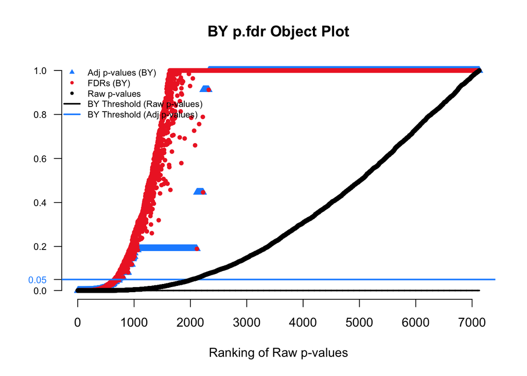

```r
plot(p.fdr.output)
```

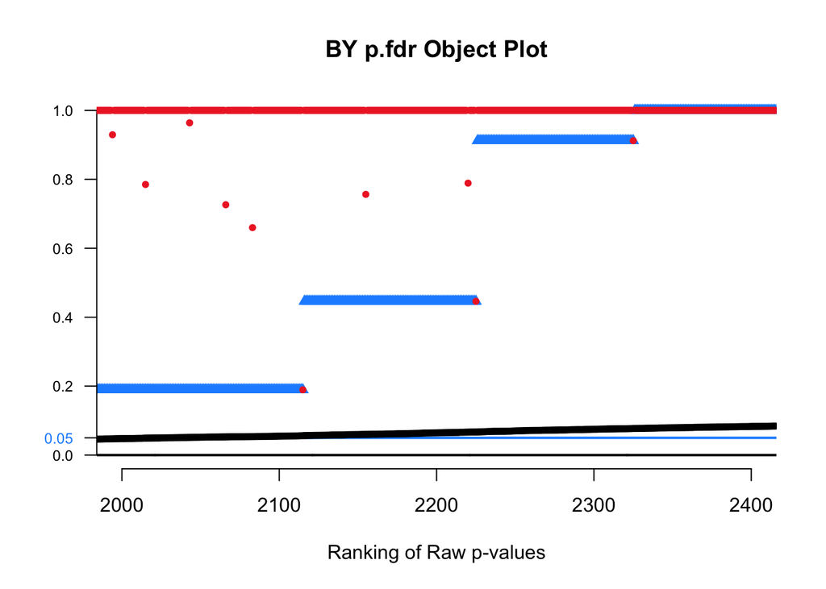

```r
plot(p.fdr.output, xlim=c(2000,2400), legend.on = FALSE)
```

#### Simple Example

```r
pvalues=c(0.005,0.049,0.05,0.051,0.7)
zvalues=qnorm(pvalues/2, lower.tail = FALSE)

p.fdr.output = p.fdr(pvalues)

adj.pvalues= p.fdr.output$`Results Matrix`$`Adjusted p-values`
adj.fdrs= p.fdr.output$fdrs

single.fdr = c(p.fdr(pvalues=pvalues[1],zvalue=zvalues[1]),
               p.fdr(pvalues=pvalues[2],zvalue=zvalues[2]),
               p.fdr(pvalues=pvalues[3],zvalue=zvalues[3]),
               p.fdr(pvalues=pvalues[4],zvalue=zvalues[4]),
               p.fdr(pvalues=pvalues[5],zvalue=zvalues[5]))
```

```r
df = data.frame("Raw p-values"= pvalues,
                "Z-values" = zvalues,
                "BH Adj p-values" = adj.pvalues,
                "BH FDRs" = adj.fdrs,
                "Single lower bound FDRs" = single.fdr)

colnames(df) = c("Raw p-values",
                "Z-values",
                "BH Adj p-values"  ,
                "BH FDRs" ,
                "Single lower bound FDRs" )

kable(round(df,3))%>%
  kable_styling(c("striped", "bordered"))
```

| Raw p-values | Z-values | BH Adj p-values | BH FDRs | Single lower bound FDRs |
| --- | --- | --- | --- | --- |
| 0.005 | 2.807 | 0.025 | 0.025 | 0.019 |
| 0.049 | 1.969 | 0.064 | 0.122 | 0.126 |
| 0.050 | 1.960 | 0.064 | 0.083 | 0.128 |
| 0.051 | 1.951 | 0.064 | 0.064 | 0.130 |
| 0.700 | 0.385 | 0.700 | 0.700 | 0.481 |

#### Compare to p.adjust

```r
set.seed(999)
pi0 <- 0.8
pi1 <- 1-pi0
n <- 10
n.0 <- ceiling(n*pi0)
n.1 <- n-n.0

sim.data <- c(rnorm(n.1,2,1),rnorm(n.0,0,1))
sim.data.p <- 2*pnorm(-abs(sim.data))

p.adjust.output = p.adjust(sim.data.p, method="fdr")

fdr.output = p.fdr(pvalues=sim.data.p, adjust.method="BH")

head(data.frame("Raw p-values"= sim.data.p,"p.adjust FDRs"=p.adjust.output,"p.fdr adj p-values"=fdr.output$`Results Matrix`$`Adjusted p-values`,"p.fdr FDRs"=fdr.output$fdrs))
```

```
##   Raw.p.values p.adjust.FDRs p.fdr.adj.p.values p.fdr.FDRs
## 1   0.08574923     0.4287462          0.4287462  0.4287462
## 2   0.49180527     0.7025790          0.7025790  0.7025790
## 3   0.42650649     0.7025790          0.7025790  0.7108441
## 4   0.78710602     0.7871060          0.7871060  0.7871060
## 5   0.78154483     0.7871060          0.7871060  0.8683831
## 6   0.57137764     0.7142221          0.7142221  0.7142221
```

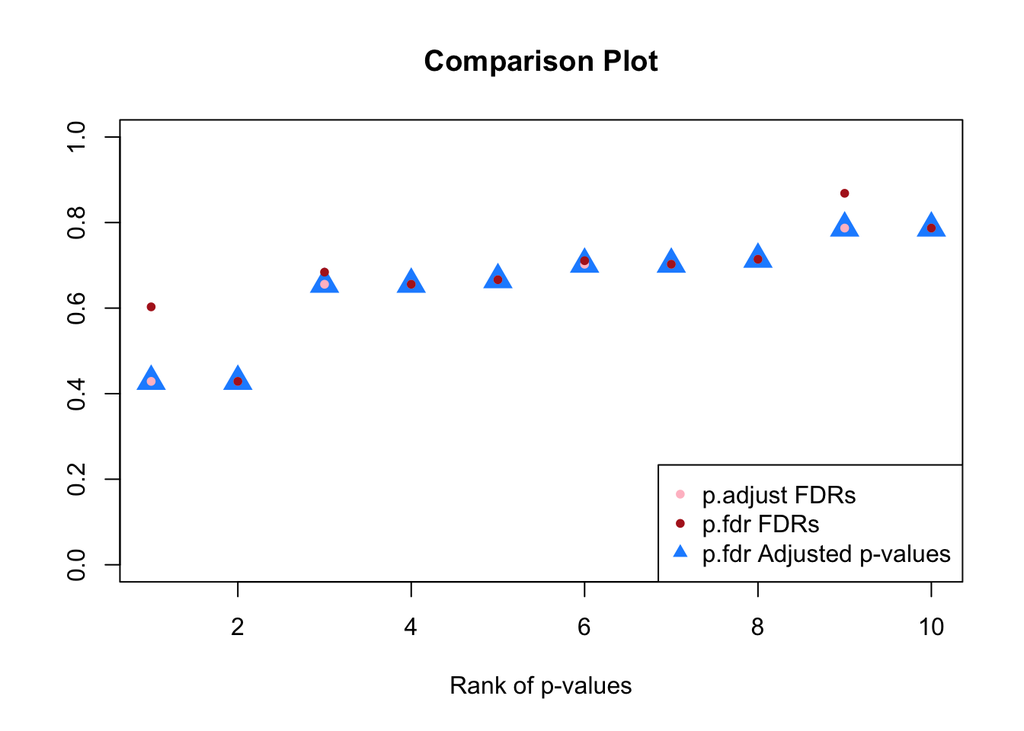

```r
plot(rank(sim.data.p, ties="random"),
     fdr.output$`Results Matrix`$`Adjusted p-values`,
     pch=17,
     col="dodgerblue",
     cex=2,
     ylim=c(0,1),
     main="Comparison Plot",
     xlab="Rank of p-values",
     ylab="")
points(rank(sim.data.p, ties="random"),p.adjust.output, pch=20, col="pink")
points(rank(sim.data.p, ties="random"),fdr.output$fdrs, pch=20, col="firebrick")
legend("bottomright", c("p.adjust FDRs", "p.fdr FDRs","p.fdr Adjusted p-values"), col=c("pink", "firebrick","dodgerblue"), pch=c(20,20,17))
```

#### Different Null proportions

```r
get.pi0(leukstats$p.value, estim.method = "last.hist")
```

```
## [1] 0.6313131
```

```r
get.pi0(leukstats$p.value, estim.method = "storey")
```

```
## [1] 0.6020751
```

```r
get.pi0(leukstats$p.value, estim.method = "set.pi0", set.pi0=0.8)
```

```
## [1] 0.8
```

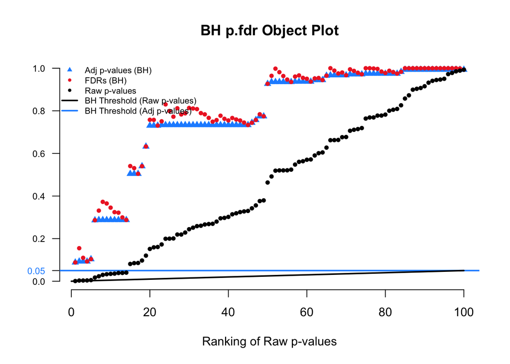

```r
set.seed(999)
pi0 <- 0.8
pi1 <- 1-pi0
n <- 100
n.0 <- ceiling(n*pi0)
n.1 <- n-n.0

sim.data <- c(rnorm(n.1,2,1),rnorm(n.0,0,1))
sim.data.p <- 2*pnorm(-abs(sim.data))

fdr.output = p.fdr(pvalues=sim.data.p, adjust.method="BH")

plot(fdr.output)
```

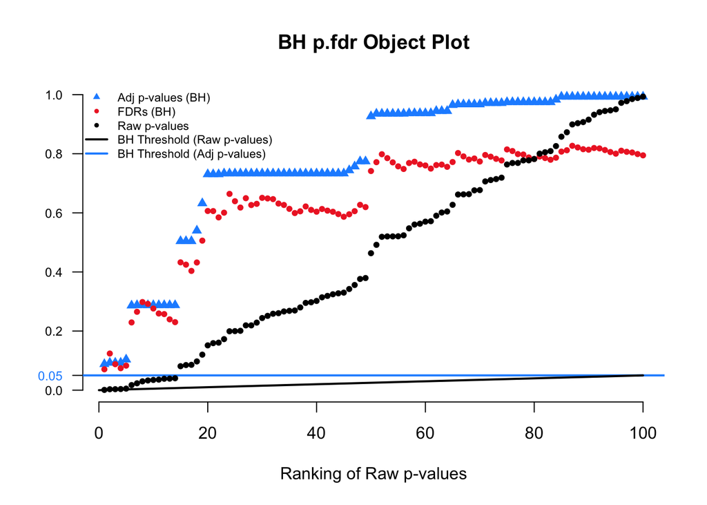

```r
fdr.output = p.fdr(pvalues=sim.data.p, adjust.method="BH", set.pi0=0.8)

plot(fdr.output)
```

```r
get.pi0(sim.data.p, estim.method = "set.pi0", set.pi0=0.7)
```

```
## [1] 0.7
```

```r
get.pi0(sim.data.p, estim.method = "last.hist")
```

```
## [1] 1
```

```r
get.pi0(sim.data.p, estim.method = "storey")
```

```
## [1] 1
```

```r
pi0 <- 0.8
pi1 <- 1-pi0
n <- 10000
n.0 <- ceiling(n*pi0)
n.1 <- n-n.0

sim.data <- c(rnorm(n.1,2,1),rnorm(n.0,0,1))
sim.data.p <- 2*pnorm(-abs(sim.data))

get.pi0(sim.data.p, estim.method = "set.pi0", set.pi0=0.7)
```

```
## [1] 0.7
```

```r
get.pi0(sim.data.p, estim.method = "last.hist")
```

```
## [1] 0.796
```

```r
get.pi0(sim.data.p, estim.method = "storey")
```

```
## [1] 0.8051147
```

##### Internal Code: Last Histogram Height Method

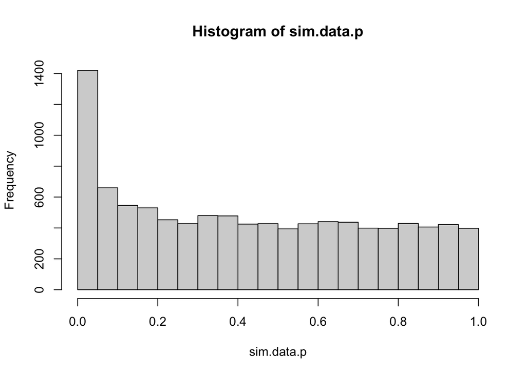

```r
try.hist = hist(sim.data.p, breaks="scott")
```

```r
try.mids = try.hist$mids
try.count = try.hist$counts

if(tail(try.mids,1)<0.5){
  pi0.hat=0
}else{
  pi0.hat = min(tail(try.count,1)*length(try.mids)/sum(try.count),1)
}

pi0.hat
```

```
## [1] 0.796
```